# Lasso regularization for selelection/specification of log-linear models

This post provides code to implement inductive selection/specification of log-linear models for contingency tables via the Lasso. I will exemplify the step-by-step implementation using data on intergenerational occupational mobility for 16 countries.

#### Steps:

1. Install and load package `glmnet`, which aperforms Lasso or elastic-net regularization path for generalized linear models. Other packages for data manipulation will be also used.

```r
    library("glmnet")
    library("tidyverse")
    library("modelr")
    library("reshape2")
```

2. Input the contingency table an turn it into a data frame. I will use the dataset `hg16` from the package `logmult`. This is a cross-classification of subject’s occupational status (destination) and his father’s occupational status (origin) across 16 countries.

```r
    # Inpute data and create contingency table as data.frame()
    library("logmult")
    data(hg16)
    table <- ftable(hg16)
    mydata <- as.data.frame(table)
    names(mydata) <- c("origin","destination","country","Freq")
```

This is what the data looks like:

| origin | destination | country | Freq |
| --- | --- | --- | --- |
| White Collar | White Collar | Australia | 292 |
| Blue Collar | White Collar | Australia | 290 |
| Farm | White Collar | Australia | 81 |
| White Collar | Blue Collar | Australia | 170 |
| Blue Collar | Blue Collar | Australia | 608 |
| Farm | Blue Collar | Australia | 171 |
| White Collar | Farm | Australia | 29 |
| Blue Collar | Farm | Australia | 37 |
| Farm | Farm | Australia | 175 |
| White Collar | White Collar | Belgium | 497 |

[output cut: 134 more lines]

3. Next, create the design matrix for the saturated sodel. In this example the saturated models contains 144 parameters.

```r
    # Set reference categories
    mydata$origin      <- relevel(mydata$origin,ref = "Farm")
    mydata$destination <- relevel(mydata$destination,ref = "Farm")
    mydata$country     <- relevel(mydata$country,ref = "Spain")
    # Outcome variable is the frequencies in the contingency table
    y <- mydata$Freq + 0.5 # add small constant to avoid problems with empty cells.
    # Creates design matrix with all three-way interactions
    formula <- as.formula( ~ .*.*.)
    x <- model.matrix(formula, mydata[,c("origin","destination","country")])
```

4. Create a vector of penalty factors.

```r
    # Penalty factors for weighted penalties.
    # Here all variables have a penalty of 1, which is equivalent to unweighted penalties.
    w <- rep(1,dim(x)[2])
    # Unsilence the lines below if you wish to implement the "adaptive lasso" based on ridge estimates
    #ridge.cv <- cv.glmnet(x,y,alpha=0,family='poisson', nfolds = 10)
    #best_ridge_coef <- as.numeric(coef(ridge.cv, s = ridge.cv$lambda.min))[-1]
    #w <- 1/(abs(best_ridge_coef))^(1)
```

5. Fit the saturated model using the `glmnet` package. In this case you should set the parameter $\alpha=1$ so that you use a Lasso penalty (alternatively, $\alpha=0$ corresponds to a ridge penalty and $\alpha=0.5$ is elastic nets). Because the dependent variable is a vector of frequencies in a contingency table I use a Poisson family with a log-link function.

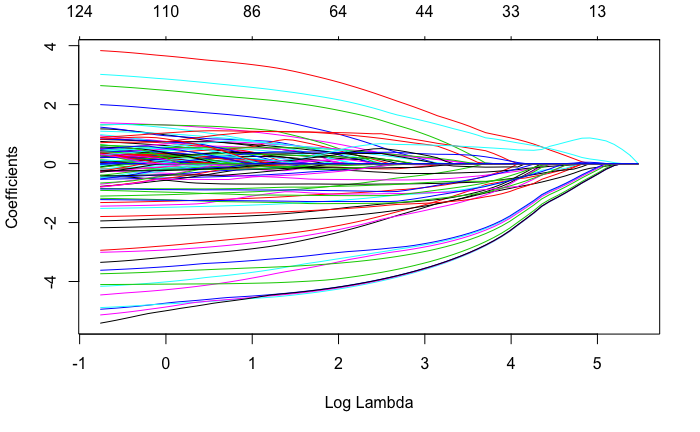

```r
    # "x" is the design matrix for the saturated model
    # "y" is the  dependent variable
    # "alpha=1" indicates the use of a Lasso penalty
    # "family=poisson" uses a log-link function by default
    # "penalty.factor = w specifies the weight for each variable's penalty

    # Fit model

    lasso <- glmnet(x,y,alpha=1,family='poisson', penalty.factor = w)
    # Plot the path of coefficients for values of lambda
    plot(lasso,xvar="lambda")
```

6. Select a value of $\lambda$ that minimizes a measure of cross-validation error. In the case of a Poisson model such measure is based on the Poisson Deviance. For this we use 10-fold cross-validation. Following the advice of the package developers I select the value of $\lambda$ that yields the most regularized model such that the error is within one standard error of the minimum.

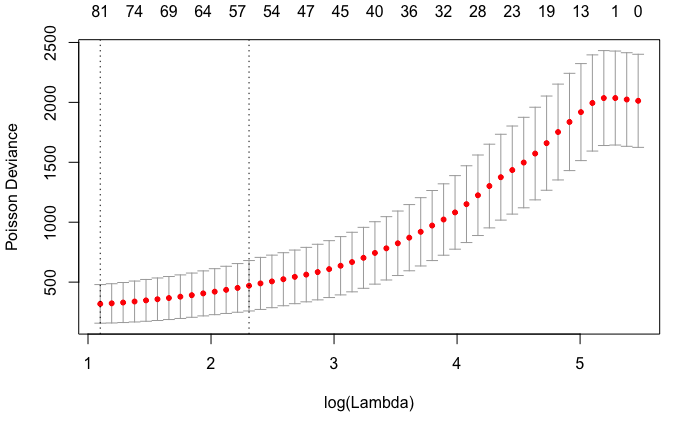

```r
    # Cross-validation of Lambda
    lasso.cv <- cv.glmnet(x,y,alpha=1,family='poisson', nfolds = 10, penalty.factor = w)
    # Plot cross-validation error for each value of lambda
    plot(lasso.cv)
```

7. Extract coefficients corresponding to the chosen value of lambda. The vector of coefficients from the Poisson model is most likely sparse.

```r
# Extract optimum value of lambda
opt.lam <- c(lasso.cv$lambda.1se)
lasso.coefs <- coef(lasso.cv, s = opt.lam)
print(lasso.coefs)
```

```
145 x 1 sparse Matrix of class "dgCMatrix"
                                                                          1
(Intercept)                                                      9.12085673
(Intercept)                                                      .
originWhite Collar                                              -2.08988473
originBlue Collar                                               -1.91262871
destinationWhite Collar                                         -0.64397157
destinationBlue Collar                                          -0.13131034
countryAustralia                                                -3.08419718
countryBelgium                                                  -3.15994469
countryFrance                                                   -1.71517333
countryHungary                                                  -0.97210452
countryItaly                                                    -3.29253459
countryJapan                                                    -2.94361973
countryPhilippines                                              -1.17843790
countryUnited States                                            -2.03696358
countryWest Germany                                             -1.43042763
countryWest Malaysia                                            -1.47979006
countryYugoslavia                                               -3.78262426
countryDenmark                                                  -4.03057779
countryFinland                                                  -4.09436467
countryNorway                                                   -4.05957652
countrySweden                                                   -4.03704431
originWhite Collar:destinationWhite Collar                       2.49071711
originBlue Collar:destinationWhite Collar                        1.61331189
originWhite Collar:destinationBlue Collar                        0.73290796
originBlue Collar:destinationBlue Collar                         1.95783664
originWhite Collar:countryAustralia                              .
originBlue Collar:countryAustralia                               0.07156901
originWhite Collar:countryBelgium                                .
originBlue Collar:countryBelgium                                 .
originWhite Collar:countryFrance                                 .
originBlue Collar:countryFrance                                  .
originWhite Collar:countryHungary                               -1.03005913
originBlue Collar:countryHungary                                 .
originWhite Collar:countryItaly                                  .
originBlue Collar:countryItaly                                   .
originWhite Collar:countryJapan                                  .
originBlue Collar:countryJapan                                   .
originWhite Collar:countryPhilippines                           -0.54757703
```

[output cut: 92 more lines]

```
originBlue Collar:destinationWhite Collar:countryDenmark         .
originWhite Collar:destinationBlue Collar:countryDenmark         .
originBlue Collar:destinationBlue Collar:countryDenmark          .
originWhite Collar:destinationWhite Collar:countryFinland        .
originBlue Collar:destinationWhite Collar:countryFinland         .
originWhite Collar:destinationBlue Collar:countryFinland         .
originBlue Collar:destinationBlue Collar:countryFinland          .
originWhite Collar:destinationWhite Collar:countryNorway         .
originBlue Collar:destinationWhite Collar:countryNorway          .
originWhite Collar:destinationBlue Collar:countryNorway          .
originBlue Collar:destinationBlue Collar:countryNorway           .
originWhite Collar:destinationWhite Collar:countrySweden         .
originBlue Collar:destinationWhite Collar:countrySweden          .
originWhite Collar:destinationBlue Collar:countrySweden          .
originBlue Collar:destinationBlue Collar:countrySweden           .
```

8. You can plot the results to easly visualize the margin-free association between origin and destination.

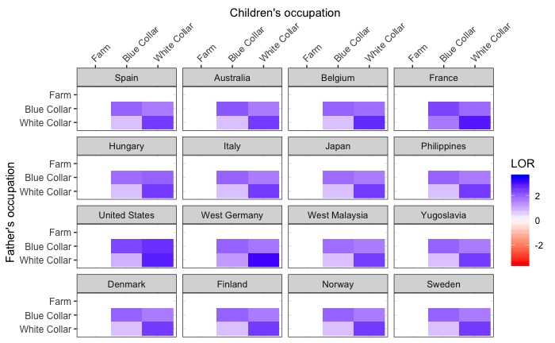